# Spectral clustering

Catherine Matias

Mars 2024

## Partie 1 : Algorithmes de spectral clustering

Le but de cette partie est d’implémenter différents algorithmes de spectral clustering et d’analyser leur comportement sur quelques graphes simples.

### Exercice 1

Rappel : La fonction `eigen()` donne le spectre d’une matrice.

1. Ecrire une fonction R qui effectue le **spectral clustering normalisé**. Cette fonction prend en argument une matrice d’adjacence et le nombre de clusters souhaité. Elle peut afficher les valeurs propres de la matrice laplacienne $L_N$ et renvoie le clustering obtenu.
2. Simuler un petit graphe dont vous connaissez les communautés et tester votre fonction. On pourra prendre par exemple un graphe avec plusieurs composantes connexes, chacune étant de loi $G(n,p)$ avec $p$ assez grand. Puis ajouter des arêtes pour rendre ce graphe connexe.
3. Faites de même pour l’**absolute spectral clustering** basé sur $L_\text{abs}$.

### Exercice 2

Simuler différents graphes et analyser le spectre des laplaciens $L_N$ et $L_{\text{abs}}$ associés. Est-ce que la méthode du trou spectral (eigengap) permet de choisir un nombre de clusters raisonnable ? Vérifier quelle méthode retrouve le bon clustering. D’ailleurs, comment compare-t-on les clusters obtenus par deux algorithmes de classification différents ? (Il faut faire attention au problème du ``label switching’’).

Quelques idées de graphes à simuler :

- un graphe $G(n,p)$ (avec une seule composante connexe) (utiliser la fonction `sample_gnp()`);
- un graphe avec deux, trois ou quatre communautés (essayer `sample_sbm()`);
- un graphe en étoile ;
- un graphe bi-partie (complet entre les deux parties) ;
- deux étoiles connectées par une arête.

### Exercice 3

Reprenez un des graphes réels vus aux TP précédents (graphe friends ou karate par exemple) et appliquez les algorithmes de clustering sur ces données. Interprétez vos résultats.

## Partie 2 : Graphes de similarité

Dans cette partie, nous analysons l’effet du choix du graphe de similarité ainsi que l’effet du choix de la méthode sur le clustering obtenu.

Nous simulons un jeu de données de $n = 100$ points $x_i$ dans $\mathbb R^2$ par les instructions suivantes :

```r
set.seed(111)
library(mlbench)
```

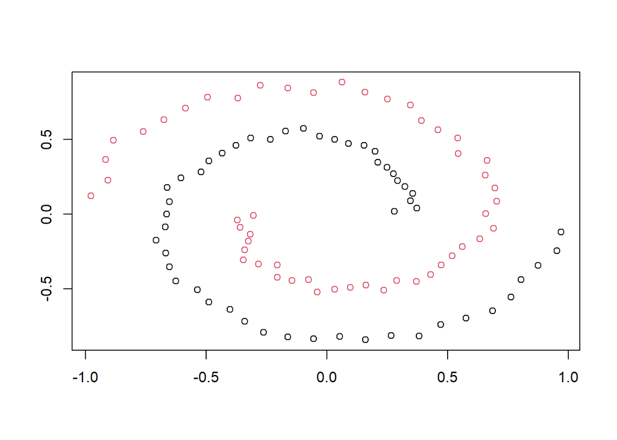

```r
n <- 100
simu <- mlbench.spirals(100, 1, 0.025)
plot(simu)
```

On obtient un jeu de données formé de deux spirales de points emboîtées. L’enjeu est des retrouver les deux groupes.

1. Pour commencer, appliquer l’algorithme k-means directement sur ces données pour faire un clustering en deux groupes. Visualiser le clustering en représentant les points en couleur. Commenter le résultat.
2. Calculer les similarités gaussienne $s_{ij}=\exp\{-\|x_i-x_j\|^2/(2\sigma^2)\}$ avec $\sigma=1$.
   - Appliquer l’algorithme de spectral clustering normalisé sur ce graphe dense pour chercher deux classes. Analyser le spectre du laplacien normalisé et visualiser le clustering obtenu.
   - Tracer le nuage des nouveaux points sur lesquels $k$-means est appliquée (ce sont les lignes de la matrice T constituée des deux premiers vecteurs propres normalisés) et ajouter en couleur les classes initiales. Interpréter les résultats.
   - Appliquer l’algorithme d’absolute spectral clustering avec deux classes. Analyser le spectre et visualiser le clustering obtenu.
3. Faites de même pour les graphes de similarité suivants :
   - On fixe $\varepsilon=q_{0.75}$ le quantile à 75% des similarités $\{s_{ij}\}_{i<j}$. Construire le graphe de $\varepsilon$-voisinage des points $\{x_i\}$.
   - On fixe $\varepsilon=q_{0.95}$ le quantile à $95\%$ des similarités $\{s_{ij}\}_{i<j}$. Construire le graphe de $\varepsilon$-voisinage des points $\{x_i\}$.
   - On fixe $p=2\lfloor \log(n)\rfloor$. Construire le graphe valué des $p$ plus proches voisins mutuels des points $\{x_i\}$.
   - On fixe $p=2$. Construire le graphe valué des $p$ plus proches voisins mutuels des points $\{x_i\}$.
   - On fixe $p=2\lfloor \log(n)\rfloor$. Construire le graphe valué des $p$ plus proches voisins simple des points $\{x_i\}$.
   - On fixe $p=2$. Construire le graphe valué des $p$ plus proches voisins simple des points $\{x_i\}$.